# IODS course project

Hari Adhikari

# About the project

OPEN DATA - OPEN SCIENCE - DATA SCIENCE We must discover the patterns hidden behind numbers in matrices and arrays. We are not afraid of coding, recoding, programming, or modelling. We want to visualize, analyze, interpret, understand, and communicate. These are the core themes of Open Data Science (Open Data - Open Science - Data Science). And this course is THE course for learning these skills.

# Link to my git repository

https://github.com/adhihari/IODS-project

# Useful link for this course

Introduction to Open Data Science https://courses.helsinki.fi/en/HYMY-909/125158217

https://mooc.helsinki.fi/course/view.php?id=158#section-0

Youtube videos https://www.youtube.com/watch?v=7BRMED2Zapo&list=PLjz3inNXiF4_QIEOwhwK0sC0ePO5xufJ8&index=1

Blogs https://blogs.helsinki.fi/thinkopen/welcome-open-data-science/

# Exercise 2

## Data wrangling and analysis

Install package and run library install.packages(ggplot2)

```r
library(ggplot2)
```

## Data Analysis 1

Now reading data from web

```r
students2014  <- read.table("http://s3.amazonaws.com/assets.datacamp.com/production/course_2218/datasets/learning2014.txt", sep=",", header =T)
```

Structure of the data

```r
str(students2014)
```

```
## 'data.frame':    166 obs. of  7 variables:
##  $ gender  : Factor w/ 2 levels "F","M": 1 2 1 2 2 1 2 1 2 1 ...
##  $ age     : int  53 55 49 53 49 38 50 37 37 42 ...
##  $ attitude: num  3.7 3.1 2.5 3.5 3.7 3.8 3.5 2.9 3.8 2.1 ...
##  $ deep    : num  3.58 2.92 3.5 3.5 3.67 ...
##  $ stra    : num  3.38 2.75 3.62 3.12 3.62 ...
##  $ surf    : num  2.58 3.17 2.25 2.25 2.83 ...
##  $ points  : int  25 12 24 10 22 21 21 31 24 26 ...
```

So it has “gender” column as Factor and “age” and “points” columns as integer, rest of the columns are numeric.

Dimension of the data

```r
dim(students2014)
```

```
## [1] 166   7
```

It has 166 rows and 7 columns

Names of columns

```r
names(students2014)
```

```
## [1] "gender"   "age"      "attitude" "deep"     "stra"     "surf"
## [7] "points"
```

## Data Analysis 2

```r
   dim(students2014)
```

```
## [1] 166   7
```

Plot the variables Lets visualize the attitude versus points and colors are given based in gender

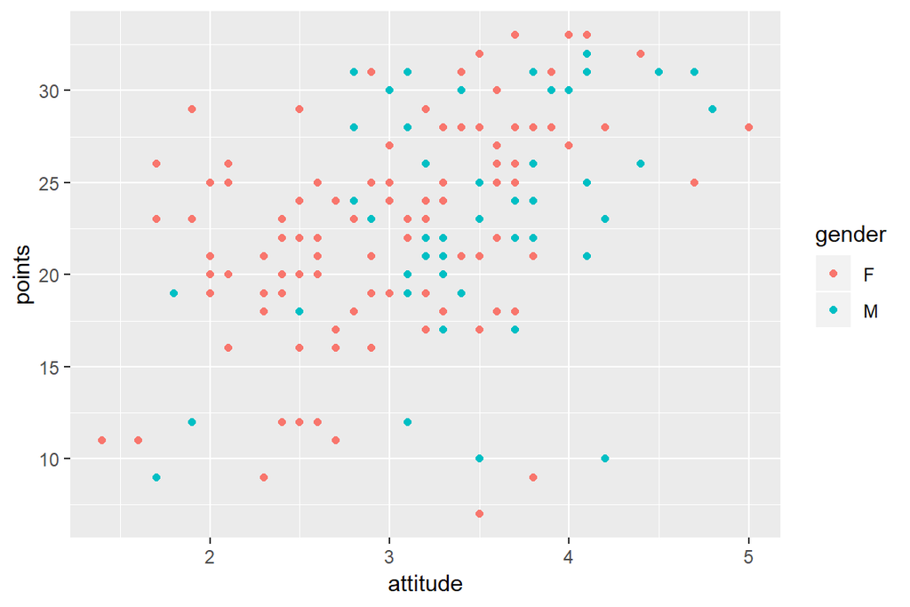

```r
library(ggplot2)
#initialize plot with data and aesthetic mapping
p1 <- ggplot(students2014, aes(x = attitude, y = points, col=gender))
#define the visualization type (points)
p2 <- p1 + geom_point()
#draw the plot
p2
```

Figure shows that the attitude and points are linearly related

See the summary of the data

```r
summary(students2014)
```

```
##  gender       age           attitude          deep            stra
##  F:110   Min.   :17.00   Min.   :1.400   Min.   :1.583   Min.   :1.250
##  M: 56   1st Qu.:21.00   1st Qu.:2.600   1st Qu.:3.333   1st Qu.:2.625
##          Median :22.00   Median :3.200   Median :3.667   Median :3.188
##          Mean   :25.51   Mean   :3.143   Mean   :3.680   Mean   :3.121
##          3rd Qu.:27.00   3rd Qu.:3.700   3rd Qu.:4.083   3rd Qu.:3.625
##          Max.   :55.00   Max.   :5.000   Max.   :4.917   Max.   :5.000
##       surf           points
##  Min.   :1.583   Min.   : 7.00
##  1st Qu.:2.417   1st Qu.:19.00
##  Median :2.833   Median :23.00
##  Mean   :2.787   Mean   :22.72
##  3rd Qu.:3.167   3rd Qu.:27.75
##  Max.   :4.333   Max.   :33.00
```

There are 110 female and 56 male

## Data Analysis 3

Create a model

```r
Model1<- lm(points ~ gender+age+attitude, data = students2014)
```

Create a summary

```r
summary(Model1)
```

```
##
## Call:
## lm(formula = points ~ gender + age + attitude, data = students2014)
##
## Residuals:
##      Min       1Q   Median       3Q      Max
## -17.4590  -3.3221   0.2186   4.0247  10.4632
##
## Coefficients:
##             Estimate Std. Error t value Pr(>|t|)
## (Intercept) 13.42910    2.29043   5.863 2.48e-08 ***
## genderM     -0.33054    0.91934  -0.360    0.720
## age         -0.07586    0.05367  -1.414    0.159
## attitude     3.60657    0.59322   6.080 8.34e-09 ***
## ---
## Signif. codes:  0 '***' 0.001 '**' 0.01 '*' 0.05 '.' 0.1 ' ' 1
##
## Residual standard error: 5.315 on 162 degrees of freedom
## Multiple R-squared:  0.2018, Adjusted R-squared:  0.187
## F-statistic: 13.65 on 3 and 162 DF,  p-value: 5.536e-08
```

Only “attitude”" is significant, so we will remove “gender” and “age” from the model Now i try to include rest of the variables except “gender” and “age” and see its significance.

```r
Model2<- lm(points ~ attitude+deep+stra+surf, data = students2014)
summary(Model2)
```

```
##
## Call:
## lm(formula = points ~ attitude + deep + stra + surf, data = students2014)
##
## Residuals:
##      Min       1Q   Median       3Q      Max
## -16.7335  -3.1992   0.7975   3.4002  11.6582
##
## Coefficients:
##             Estimate Std. Error t value Pr(>|t|)
## (Intercept)  15.4000     5.0245   3.065  0.00255 **
## attitude      3.4362     0.5739   5.987 1.34e-08 ***
## deep         -1.0072     0.7870  -1.280  0.20247
## stra          0.8847     0.5411   1.635  0.10398
## surf         -0.9105     0.8390  -1.085  0.27948
## ---
## Signif. codes:  0 '***' 0.001 '**' 0.01 '*' 0.05 '.' 0.1 ' ' 1
##
## Residual standard error: 5.286 on 161 degrees of freedom
## Multiple R-squared:  0.2154, Adjusted R-squared:  0.1959
## F-statistic: 11.05 on 4 and 161 DF,  p-value: 6.057e-08
```

Now we see that except “attitude” all other variables are insignificant So we make a model 3 by just using “attitude” as predictor variables

## Data Analysis 4

```r
Model3<- lm(points ~ attitude, data = students2014)
summary(Model3)
```

```
##
## Call:
## lm(formula = points ~ attitude, data = students2014)
##
## Residuals:
##      Min       1Q   Median       3Q      Max
## -16.9763  -3.2119   0.4339   4.1534  10.6645
##
## Coefficients:
##             Estimate Std. Error t value Pr(>|t|)
## (Intercept)  11.6372     1.8303   6.358 1.95e-09 ***
## attitude      3.5255     0.5674   6.214 4.12e-09 ***
## ---
## Signif. codes:  0 '***' 0.001 '**' 0.01 '*' 0.05 '.' 0.1 ' ' 1
##
## Residual standard error: 5.32 on 164 degrees of freedom
## Multiple R-squared:  0.1906, Adjusted R-squared:  0.1856
## F-statistic: 38.61 on 1 and 164 DF,  p-value: 4.119e-09
```

## Data Analysis 5

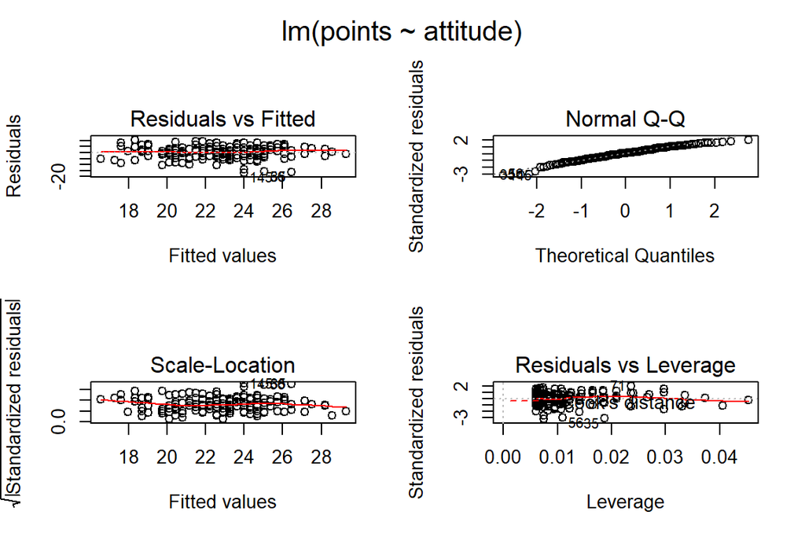

```r
## 4 plots on 1 page;
## allow room for printing model formula in outer margin:
par(mfrow = c(2, 2), oma = c(0, 0, 2, 0))
plot(Model3)
```

# Exercise 3

## Data Wrangling

See https://github.com/adhihari/IODS-project/blob/master/data/create_alc.R

We run libraries of “dplyr” and “ggplot2” install.packages(“ggplot2”)

Now we are reading the joined data set used in the analysis exercise combines the two student alcohol consumption data sets.

### Some background about the data

The following adjustments have been made:

The variables not used for joining the two data have been combined by averaging (including the grade variables) ‘alc_use’ is the average of ‘Dalc’ and ‘Walc’ ‘high_use’ is TRUE if ‘alc_use’ is higher than 2 and FALSE otherwise.

Although we have saved the alc.txt file in the data wrangling exercise, we are going to use alc.txt from the website Here we will print the names of the columns in the dataframe and also see the structure of the data

## Data Analysis

#### Now reading data from web

```r
alc  <- read.table("http://s3.amazonaws.com/assets.datacamp.com/production/course_2218/datasets/alc.txt", sep=",", header =T)
#names of colums present in the data
print(names(alc))
```

```
##  [1] "school"     "sex"        "age"        "address"    "famsize"
##  [6] "Pstatus"    "Medu"       "Fedu"       "Mjob"       "Fjob"
## [11] "reason"     "nursery"    "internet"   "guardian"   "traveltime"
## [16] "studytime"  "failures"   "schoolsup"  "famsup"     "paid"
## [21] "activities" "higher"     "romantic"   "famrel"     "freetime"
## [26] "goout"      "Dalc"       "Walc"       "health"     "absences"
## [31] "G1"         "G2"         "G3"         "alc_use"    "high_use"
```

```r
print(str(alc))
```

```
## 'data.frame':    382 obs. of  35 variables:
##  $ school    : Factor w/ 2 levels "GP","MS": 1 1 1 1 1 1 1 1 1 1 ...
##  $ sex       : Factor w/ 2 levels "F","M": 1 1 1 1 1 2 2 1 2 2 ...
##  $ age       : int  18 17 15 15 16 16 16 17 15 15 ...
##  $ address   : Factor w/ 2 levels "R","U": 2 2 2 2 2 2 2 2 2 2 ...
##  $ famsize   : Factor w/ 2 levels "GT3","LE3": 1 1 2 1 1 2 2 1 2 1 ...
##  $ Pstatus   : Factor w/ 2 levels "A","T": 1 2 2 2 2 2 2 1 1 2 ...
##  $ Medu      : int  4 1 1 4 3 4 2 4 3 3 ...
##  $ Fedu      : int  4 1 1 2 3 3 2 4 2 4 ...
##  $ Mjob      : Factor w/ 5 levels "at_home","health",..: 1 1 1 2 3 4 3 3 4 3 ...
##  $ Fjob      : Factor w/ 5 levels "at_home","health",..: 5 3 3 4 3 3 3 5 3 3 ...
##  $ reason    : Factor w/ 4 levels "course","home",..: 1 1 3 2 2 4 2 2 2 2 ...
##  $ nursery   : Factor w/ 2 levels "no","yes": 2 1 2 2 2 2 2 2 2 2 ...
##  $ internet  : Factor w/ 2 levels "no","yes": 1 2 2 2 1 2 2 1 2 2 ...
##  $ guardian  : Factor w/ 3 levels "father","mother",..: 2 1 2 2 1 2 2 2 2 2 ...
```

[output cut: 22 more lines]

```r
print(dim(alc))
```

```
## [1] 382  35
```

Now we see that the data frame has 382 rows and 35 columns.

We also see that we have factor, numeric, integers, and logical data types in the data frame.

###### I think that student consume more alcohol when there is lack of parential guidence,i assume that more educated father can guide his child for better future and discourage him/her for alchol consumption.

###### Next, i assume that if a student is romantic, for example if he has tragedy in life, he/she might consume more alcohol.

###### Next, Absent in class might indirectly means he is going to bar and has hangover

###### Next, failures in previous years might lead him/her to drink alchol.

#### Data types

So, i am going to see the relationships between low/high alcohol consumption and 4 different predictor variables, First i want to plot the relationships and make some analysis.

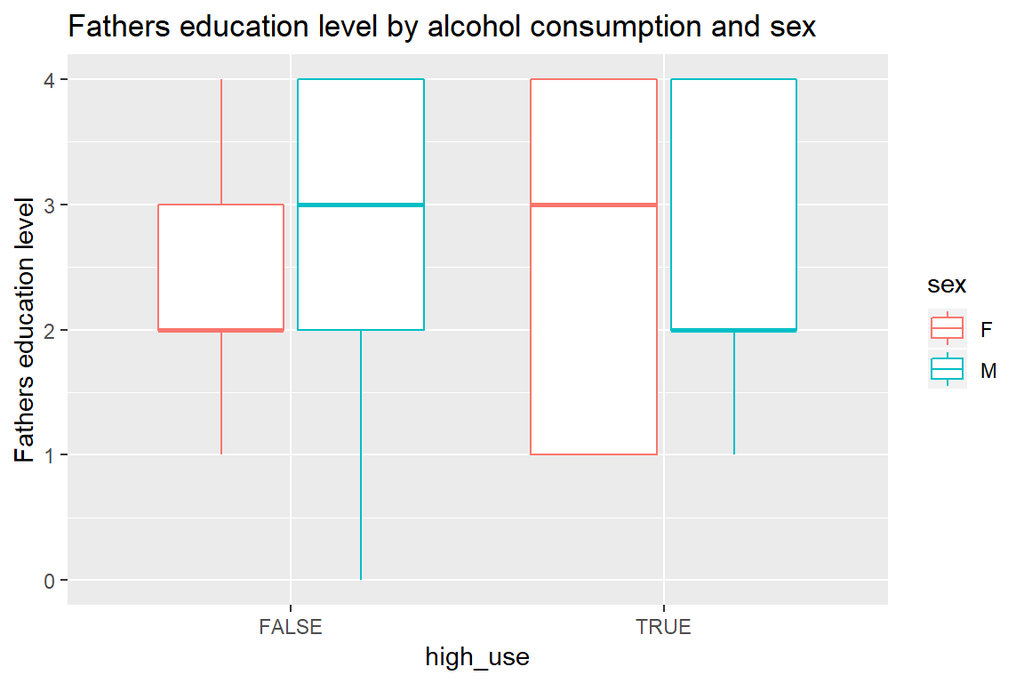

```r
# Plot high_use of alchol (true or false) based on fathers education and also see if the results differ if student is boy or girl
Feduplot <- ggplot(alc, aes(x = high_use, y = Fedu, col = sex))

# define the plot as a boxplot and draw it
Feduplot + geom_boxplot() + ylab("Fathers education level") +ggtitle("Fathers education level by alcohol consumption and sex")
```

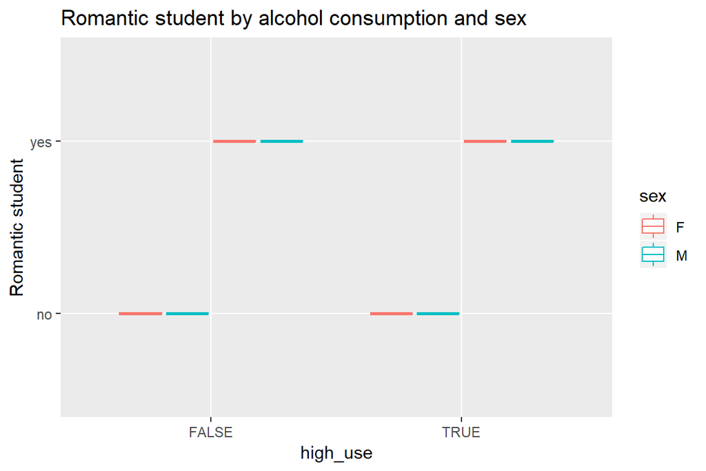

```r
# Plot high_use of alchol (true or false) based on student being romantic or not and if the results differ if student is boy or girl
Romplot <- ggplot(alc, aes(x = high_use, y = romantic, col = sex))

# define the plot as a boxplot and draw it
Romplot + geom_boxplot() + ylab("Romantic student") +ggtitle("Romantic student by alcohol consumption and sex")
```

There is no clear explanation based on student being romantic or not.

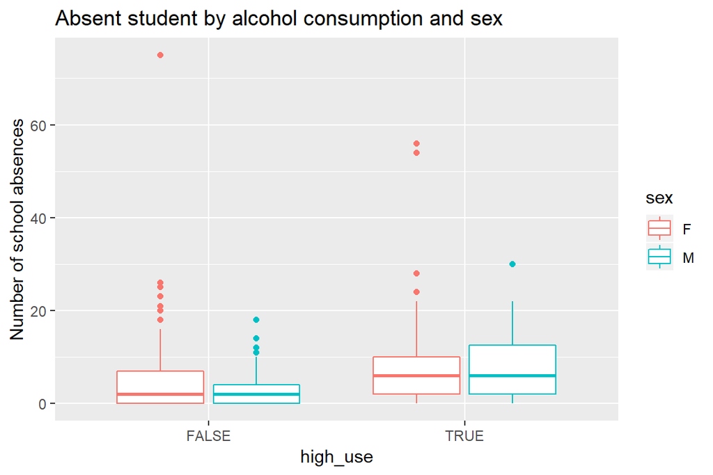

```r
# Plot high_use of alchol (true or false) based on student being absent for many days in the school and if the results differ if student is boy or girl
Romplot <- ggplot(alc, aes(x = high_use, y = absences, col = sex))

# define the plot as a boxplot and draw it
Romplot + geom_boxplot() + ylab("Number of school absences") +ggtitle("Absent student by alcohol consumption and sex")
```

names(alc)

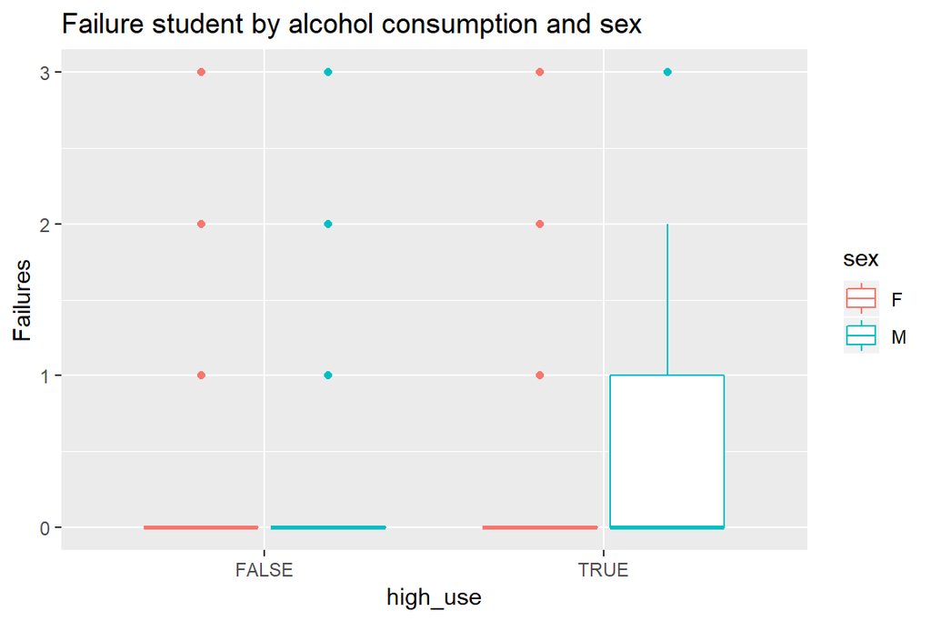

```r
# Plot high_use of alchol (true or false) based on student being fail in previous years in the school and if the results differ if student is boy or girl
Failplot <- ggplot(alc, aes(x = high_use, y = failures, col = sex))

# define the plot as a boxplot and draw it
Failplot + geom_boxplot() + ylab("Failures") +ggtitle("Failure student by alcohol consumption and sex")
```

Mostly one time fail male students tends to drink more alchol.

## Logistic regression

Here, i will use glm() function. “high_use” will be our response variable and “Fedu”, “romantic”, “absences” and “failures” as predictor variables for our logistic regression.

```r
model1 <- glm(high_use ~ Fedu +romantic + absences + failures, data = alc, family = "binomial")
summary(model1)
```

```
##
## Call:
## glm(formula = high_use ~ Fedu + romantic + absences + failures,
##     family = "binomial", data = alc)
##
## Deviance Residuals:
##     Min       1Q   Median       3Q      Max
## -2.6407  -0.7909  -0.7013   1.1088   1.9363
##
## Coefficients:
##             Estimate Std. Error z value Pr(>|z|)
## (Intercept) -1.54538    0.34269  -4.510  6.5e-06 ***
## Fedu         0.08936    0.11122   0.803 0.421697
## romanticyes -0.34134    0.26015  -1.312 0.189483
## absences     0.06885    0.01794   3.837 0.000124 ***
## failures     0.46319    0.15390   3.010 0.002615 **
## ---
## Signif. codes:  0 '***' 0.001 '**' 0.01 '*' 0.05 '.' 0.1 ' ' 1
##
## (Dispersion parameter for binomial family taken to be 1)
##
##     Null deviance: 462.21  on 381  degrees of freedom
## Residual deviance: 433.42  on 377  degrees of freedom
## AIC: 443.42
##
## Number of Fisher Scoring iterations: 4
```

# Exercise 4

## Data Analysis

#### Access the MASS package

```r
library(MASS)
#install.packages('corrplot')
library(corrplot)
```

#### Then read the Boston data from the Mass Package, its in R studio memory, so i can directly fetch them.

```r
# load the data
data("Boston")

# explore the dataset
str(Boston)
```

```
## 'data.frame':    506 obs. of  14 variables:
##  $ crim   : num  0.00632 0.02731 0.02729 0.03237 0.06905 ...
##  $ zn     : num  18 0 0 0 0 0 12.5 12.5 12.5 12.5 ...
##  $ indus  : num  2.31 7.07 7.07 2.18 2.18 2.18 7.87 7.87 7.87 7.87 ...
##  $ chas   : int  0 0 0 0 0 0 0 0 0 0 ...
##  $ nox    : num  0.538 0.469 0.469 0.458 0.458 0.458 0.524 0.524 0.524 0.524 ...
##  $ rm     : num  6.58 6.42 7.18 7 7.15 ...
##  $ age    : num  65.2 78.9 61.1 45.8 54.2 58.7 66.6 96.1 100 85.9 ...
##  $ dis    : num  4.09 4.97 4.97 6.06 6.06 ...
##  $ rad    : int  1 2 2 3 3 3 5 5 5 5 ...
##  $ tax    : num  296 242 242 222 222 222 311 311 311 311 ...
##  $ ptratio: num  15.3 17.8 17.8 18.7 18.7 18.7 15.2 15.2 15.2 15.2 ...
##  $ black  : num  397 397 393 395 397 ...
##  $ lstat  : num  4.98 9.14 4.03 2.94 5.33 ...
##  $ medv   : num  24 21.6 34.7 33.4 36.2 28.7 22.9 27.1 16.5 18.9 ...
```

```r
dim(Boston)
```

```
## [1] 506  14
```

We see that we have numerical and interger variables. So we have 506 rows and 14 columns.

#### Now we see the summary of the Boston data and also plot correlation between each variables.

```r
summary(Boston)
```

```
##       crim                zn             indus            chas
##  Min.   : 0.00632   Min.   :  0.00   Min.   : 0.46   Min.   :0.00000
##  1st Qu.: 0.08204   1st Qu.:  0.00   1st Qu.: 5.19   1st Qu.:0.00000
##  Median : 0.25651   Median :  0.00   Median : 9.69   Median :0.00000
##  Mean   : 3.61352   Mean   : 11.36   Mean   :11.14   Mean   :0.06917
##  3rd Qu.: 3.67708   3rd Qu.: 12.50   3rd Qu.:18.10   3rd Qu.:0.00000
##  Max.   :88.97620   Max.   :100.00   Max.   :27.74   Max.   :1.00000
##       nox               rm             age              dis
##  Min.   :0.3850   Min.   :3.561   Min.   :  2.90   Min.   : 1.130
##  1st Qu.:0.4490   1st Qu.:5.886   1st Qu.: 45.02   1st Qu.: 2.100
##  Median :0.5380   Median :6.208   Median : 77.50   Median : 3.207
##  Mean   :0.5547   Mean   :6.285   Mean   : 68.57   Mean   : 3.795
##  3rd Qu.:0.6240   3rd Qu.:6.623   3rd Qu.: 94.08   3rd Qu.: 5.188
##  Max.   :0.8710   Max.   :8.780   Max.   :100.00   Max.   :12.127
##       rad              tax           ptratio          black
##  Min.   : 1.000   Min.   :187.0   Min.   :12.60   Min.   :  0.32
##  1st Qu.: 4.000   1st Qu.:279.0   1st Qu.:17.40   1st Qu.:375.38
##  Median : 5.000   Median :330.0   Median :19.05   Median :391.44
##  Mean   : 9.549   Mean   :408.2   Mean   :18.46   Mean   :356.67
##  3rd Qu.:24.000   3rd Qu.:666.0   3rd Qu.:20.20   3rd Qu.:396.23
##  Max.   :24.000   Max.   :711.0   Max.   :22.00   Max.   :396.90
##      lstat            medv
##  Min.   : 1.73   Min.   : 5.00
##  1st Qu.: 6.95   1st Qu.:17.02
##  Median :11.36   Median :21.20
##  Mean   :12.65   Mean   :22.53
##  3rd Qu.:16.95   3rd Qu.:25.00
##  Max.   :37.97   Max.   :50.00
```

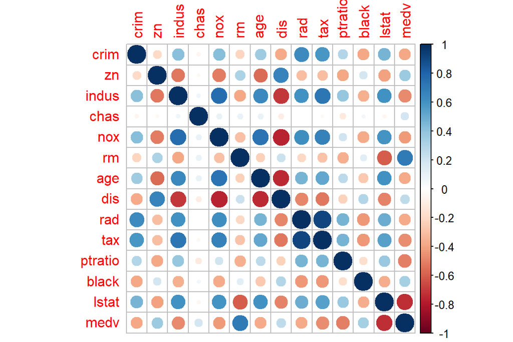

```r
# calculate the correlation matrix and round it
cor_matrix<-cor(Boston)

# print the correlation matrix
cor_matrix<- round(cor_matrix, 2)

# visualize the correlation matrix
corrplot(cor_matrix, method="circle")
```

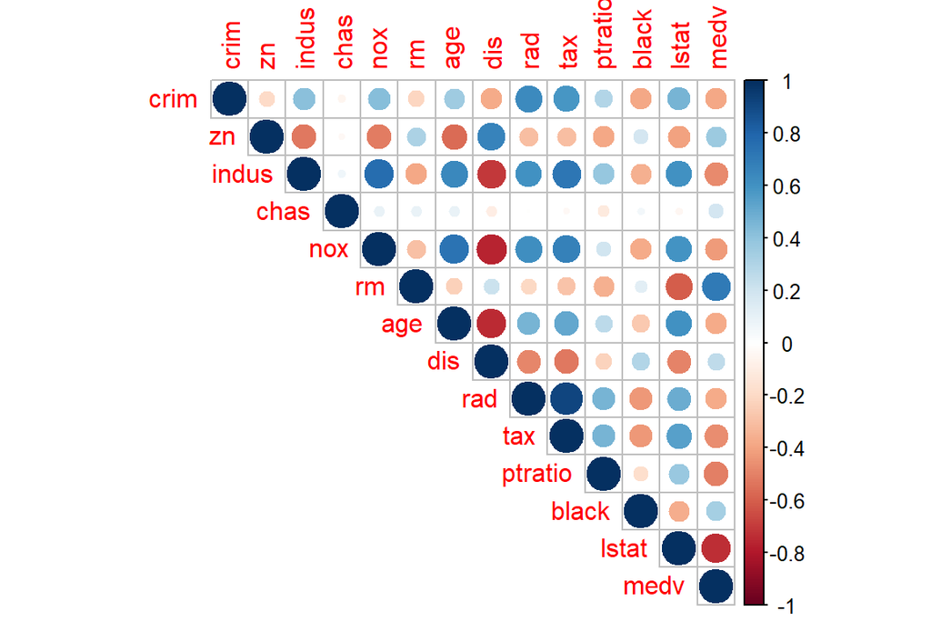

```r
corrplot(cor_matrix, method="circle", type='upper')
```

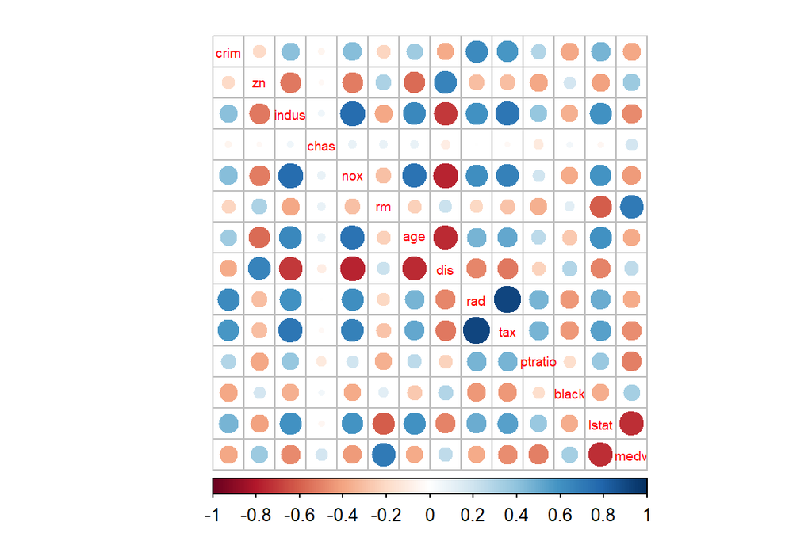

```r
corrplot(cor_matrix, method="circle", cl.pos = "b", tl.pos = "d",tl.cex = 0.6)
```

The figure above shows that  
there is high correlation between “rad” index of accessibility to radial highways and  
“tax” full-value property-tax rate per $10,000.  
There is high negative correlation between “lstat” lower status of the population (percent) and  
“medv” median value of owner-occupied homes in $1000s

This data frame contains the following columns:  
crim =per capita crime rate by town.  
zn = proportion of residential land zoned for lots over 25,000 sq.ft.  
indus = proportion of non-retail business acres per town.  
chas = Charles River dummy variable (= 1 if tract bounds river; 0 otherwise).  
nox = nitrogen oxides concentration (parts per 10 million).  
rm = average number of rooms per dwelling.  
age = proportion of owner-occupied units built prior to 1940.  
dis = weighted mean of distances to five Boston employment centres.  
rad = index of accessibility to radial highways.  
tax = full-value property-tax rate per $10,000.  
ptratio = pupil-teacher ratio by town.  
black = 1000(Bk - 0.63)^2 where Bk is the proportion of blacks by town.  
lstat = lower status of the population (percent).  
medv = median value of owner-occupied homes in $1000s